# Session 1 — Foundations

Theory of Regression Analysis · Topics 1–2 · Lab 1

Community Medicine Workshop

## Theory of Regression Analysis

**A full-day workshop for community medicine residents and faculty**

| Time | Session | Topics |
| --- | --- | --- |
| 09:00 – 10:00 | **1 · Foundations** + Lab 1 | What regression is · choosing a model |
| 10:00 – 11:15 | **2 · Simple linear regression** + Lab 2 | Equation · prediction · R² · centering |
| 11:15 – 11:30 | *Tea* |  |
| 11:30 – 13:00 | **3 · Inference & multiple regression** + Lab 3 | β, p, CI · confounding · dummy variables · model building |
| 13:00 – 13:45 | *Lunch* |  |
| 13:45 – 14:30 | **4 · Assumptions** + Lab 4 | Linearity · independence · normality · variance · collinearity |
| 14:30 – 16:10 | **5 · Logistic regression** + Lab 5 | Odds · likelihood · ROC · OR vs PR |
| 16:10 – 16:25 | *Tea* |  |
| 16:25 – 17:15 | **6 · Interpreting & reporting** + Lab 6 | Writing results · pitfalls · what next |

## Our running example

> *“Does eating more salt raise blood pressure in our community — and by how much?”*
- A **simulated** NCD survey: **600 adults aged 30–69** across **20 villages** in an Indian community setting
- Outcomes: **systolic BP** (continuous) and **hypertension** (yes/no)
- Exposure of interest: **daily salt intake** (g/day)
- Other variables: age, sex, residence, education, BMI, waist, tobacco, alcohol, physical activity
- All six sessions and labs use the same dataset

# Topic 1 — What is regression?

## What is regression?

Regression describes how the **average** value of an **outcome** changes with one or more **predictors**.

- “Among adults who eat 8 g of salt a day, the *average* SBP is …”
- “For each extra 1 g/day of salt, average SBP is … mmHg higher”
- One equation gives **description**, **comparison** and **prediction**

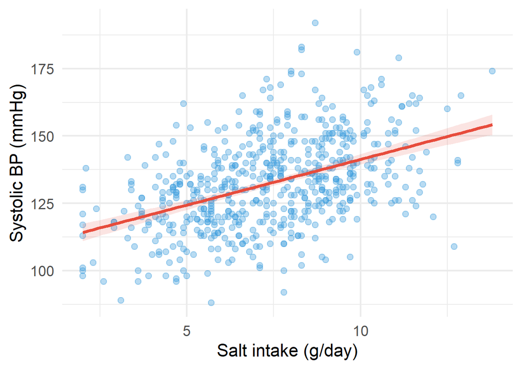

## Why do we use regression?

1. **Describe** an association with a number in real units
2. **Adjust** for other factors (age, BMI …) — the key idea in observational public health research
3. **Predict** an outcome for a new person or community
4. **Test** a hypothesis with a confidence interval

**Why not just a t-test or chi-square?**

- They compare groups, one variable at a time
- Regression handles **continuous exposures**, **many variables at once**, and gives an **effect size** (not only a p-value)

## Regression in community medicine

| Public health question | Outcome | Typical model |
| --- | --- | --- |
| Is household wealth associated with child haemoglobin (NFHS)? | Hb (g/dL) – continuous | Linear |
| Which factors predict hypertension in a screening camp? | Hypertension – binary | Logistic |
| Rainfall and monthly dengue cases per ward | Count | Poisson / neg. binomial |
| Stage of diabetic retinopathy and duration of diabetes | Ordered categories | Ordinal logistic |
| Time to treatment failure in DOTS patients | Time-to-event | Cox |
| Blood pressure of patients repeated across visits in one PHC | Repeated measures | Mixed model / GEE |

## Correlation vs regression: same data

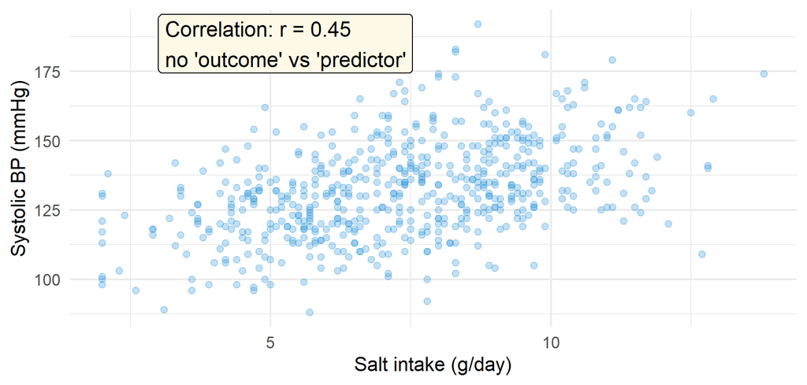

## Correlation vs regression: same data

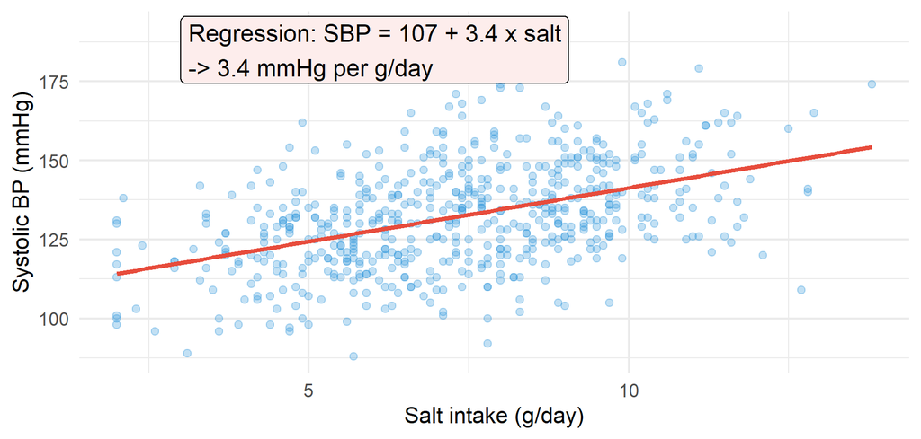

## Correlation vs regression: the differences

```r
cor(ncd$sbp, ncd$salt_g, use = "complete.obs")        # symmetric, unit-free
```

```
[1] 0.4489003
```

```r
coef(lm(sbp ~ salt_g, data = ncd))["salt_g"]           # directional, in mmHg per g
```

```
  salt_g
3.389337
```

```r
coef(lm(salt_g ~ sbp, data = ncd))["sbp"]              # swap the roles -> a different slope
```

```
       sbp
0.05945456
```

|  | Correlation (r) | Regression (β) |
| --- | --- | --- |
| Roles of X and Y | Symmetric | **Outcome** and **predictor** |
| Units | None (−1 to +1) | **Outcome units per predictor unit** |
| Adjust for other variables | No | **Yes** |
| Predict new values | No | **Yes** |

## Dependent vs independent variables

| Role | Also called | In our survey |
| --- | --- | --- |
| **Dependent** variable | outcome, response, Y | SBP, hypertension |
| **Independent** variable | predictor, exposure, X, covariate | salt intake, age, BMI … |
| **Confounder** | adjustment variable | age, BMI (related to salt *and* SBP) |

“Dependent” is a **modelling role**, not a statement of causation. The same variable can be an outcome in one analysis and a predictor in another (BMI!).

## Type of outcome decides the model

**Continuous**

- SBP (mmHg), BMI, Hb
- Summarised by mean ± SD
- → **linear regression**

**Categorical**

- Binary: hypertension yes/no
- Nominal: facility chosen (PHC / CHC / private)
- Ordinal: BP stage 1 / 2 / 3
- Plus **counts** and **time-to-event**

The first question in any regression analysis is not “which software?” but **“what type of outcome do I have?”**

# Choosing a model

## The model-selection flowchart

```
%%{init: {'flowchart': {'nodeSpacing': 16, 'rankSpacing': 45, 'padding': 14, 'htmlLabels': false}, 'themeVariables': {'fontSize': '19px', 'fontFamily': 'Arial, Helvetica, sans-serif'}}}%%
flowchart LR
  Q{{"What type of<br/>outcome<br/>do you have?"}}
  Q --> C["Continuous (SBP, BMI, Hb)"] --> L["Linear regression ✅ S2–4"]
  Q --> B["Binary (HTN yes/no)"] --> LG["Logistic regression ✅ S5"]
  LG -.-> PR["Common outcome → prevalence ratio:<br/>Poisson (robust SE) / log-binomial ✅ S5"]
  Q --> N["Count (cases per ward)"] --> P["Poisson / negative binomial"]
  Q --> O["Ordinal (stage 1–3)"] --> OL["Ordinal logistic"]
  Q --> NM["Nominal (3+ unordered)"] --> M["Multinomial logistic"]
  Q --> T["Time-to-event"] --> CX["Cox regression"]
  Q --> CL["Clustered / repeated<br/>(villages, visits)"] --> MM["Mixed models / GEE<br/>(mention only)"]
  classDef today fill:#d5f5e3,stroke:#27ae60,stroke-width:3px,color:#145a32;
  classDef later fill:#f2f3f4,stroke:#aab7b8,color:#566573;
  class L,LG,PR today;
  class P,OL,M,CX,MM later;
```

## Flowchart in practice: our survey

| Question | Outcome type | Model | Today? |
| --- | --- | --- | --- |
| By how much does SBP change per gram of salt? | Continuous | Linear | ✔ S2–4 |
| What are the odds of hypertension per gram of salt? | Binary | Logistic | ✔ S5 |
| How many times *more prevalent* is HTN in 50+ vs <50? | Binary, common | Poisson-robust | ✔ S5 |
| Number of NCD clinic visits last year | Count | Poisson / NB | later |
| Time until a hypertensive starts treatment | Time-to-event | Cox | later |
| Villages share unmeasured factors | Clustered | Mixed / GEE | mention |

# Meet the data

## Data dictionary

| Variable | Meaning | Type |
| --- | --- | --- |
| `id`, `village` | Participant ID; village (20 clusters) | ID / cluster |
| `age`, `sex`, `residence`, `education` | Demographics (4 education levels) | numeric / categorical |
| `bmi`, `waist` | kg/m², cm | continuous |
| `salt_g` | Daily salt intake (g) | continuous |
| `tobacco`, `alcohol`, `phys_act` | Yes/No; low/moderate/high | categorical |
| `sbp`, `dbp` | Blood pressure (mmHg) | continuous (**outcomes**) |
| `htn` | SBP ≥ 140 **or** DBP ≥ 90 | binary (**outcome**) |

## Import and inspect

```r
library(tidyverse)
ncd_raw <- read_csv("../data/ncd_survey.csv")
glimpse(ncd_raw)
```

```
Rows: 600
Columns: 15
$ id        <dbl> 1, 2, 3, 4, 5, 6, 7, 8, 9, 10, 11, 12, 13, 14, 15, 16, 17, 1…
$ village   <chr> "V01", "V01", "V01", "V01", "V01", "V01", "V01", "V01", "V01…
$ age       <dbl> 42, 52, 46, 56, 30, 42, 52, 52, 42, 61, 45, 55, 48, 60, 55, …
$ sex       <chr> "Female", "Female", "Male", "Male", "Male", "Female", "Femal…
$ residence <chr> "Rural", "Rural", "Rural", "Rural", "Rural", "Rural", "Rural…
$ education <chr> "Primary", "Primary", "Graduate+", "Primary", "Graduate+", "…
$ bmi       <dbl> 26.3, 21.7, 17.4, 24.1, 22.8, 26.3, 26.0, 26.1, 16.8, 28.3, …
$ waist     <dbl> 88.2, 74.4, 69.1, 85.9, 78.8, 85.5, 88.2, 80.5, 62.8, 89.7, …
$ salt_g    <dbl> 6.9, 9.0, 5.8, 10.2, 6.3, 8.9, 11.0, 9.7, 4.5, 10.8, 8.0, 6.…
$ tobacco   <chr> "No", "No", "No", "No", "No", "No", "Yes", "No", "No", "No",…
$ alcohol   <chr> "Yes", "No", "No", "No", "No", "No", "No", "No", "No", "Yes"…
$ phys_act  <chr> "moderate", "low", "high", "moderate", "low", "low", "modera…
$ sbp       <dbl> 131, 135, 127, 155, 138, 135, 126, 136, 125, 147, 122, 153, …
$ dbp       <dbl> 57, 61, 57, 79, 63, 61, 58, 64, 60, 68, 53, 66, 69, 63, 70, …
$ htn       <dbl> 0, 0, 0, 1, 0, 0, 0, 0, 0, 1, 0, 1, 1, 0, 1, 0, 0, 0, 0, 0, …
```

## Missing values

```r
ncd_raw |> summarise(across(everything(), ~ sum(is.na(.x)))) |>
  pivot_longer(everything()) |> filter(value > 0)
```

```
# A tibble: 3 × 2
  name      value
  <chr>     <int>
1 education    15
2 bmi          18
3 salt_g       18
```

Three variables have about 3% missing. A regression model **silently drops** these rows (complete-case analysis) — so n changes from model to model unless you plan for it.

## Table 1 with `tbl_summary()`

```r
library(gtsummary)
ncd |>
  select(age, sex, residence, education, bmi, salt_g, tobacco, alcohol, phys_act, htn_f) |>
  tbl_summary(by = htn_f, missing_text = "(Missing)") |>
  add_overall() |> add_p()
```

## Table 1 with `tbl_summary()`

| **Characteristic** | **Overall** N = 600<sup>1</sup> | **No HTN** N = 408<sup>1</sup> | **HTN** N = 192<sup>1</sup> | **p-value**<sup>2</sup> |
| --- | --- | --- | --- | --- |
| age | 49 (41, 56) | 45 (38, 53) | 55 (49, 62) | <0.001 |
| sex |  |  |  | 0.002 |
| Female | 284 (47%) | 211 (52%) | 73 (38%) |  |
| Male | 316 (53%) | 197 (48%) | 119 (62%) |  |
| residence |  |  |  | >0.9 |
| Urban | 202 (34%) | 137 (34%) | 65 (34%) |  |
| Rural | 398 (66%) | 271 (66%) | 127 (66%) |  |
| education |  |  |  | 0.014 |
| No schooling | 87 (15%) | 49 (12%) | 38 (20%) |  |
| Primary | 153 (26%) | 101 (25%) | 52 (28%) |  |
| Secondary | 147 (25%) | 98 (25%) | 49 (26%) |  |
| Graduate+ | 198 (34%) | 149 (38%) | 49 (26%) |  |
| (Missing) | 15 | 11 | 4 |  |
| bmi | 22.8 (20.5, 25.5) | 22.2 (19.9, 24.7) | 24.2 (21.9, 26.7) | <0.001 |
| (Missing) | 18 | 11 | 7 |  |
| salt_g | 7.40 (5.70, 9.00) | 6.60 (5.20, 8.50) | 8.60 (7.20, 9.70) | <0.001 |
| (Missing) | 18 | 11 | 7 |  |
| tobacco | 180 (30%) | 106 (26%) | 74 (39%) | 0.002 |
| alcohol | 128 (21%) | 71 (17%) | 57 (30%) | <0.001 |
| phys_act |  |  |  | 0.9 |
| low | 182 (30%) | 125 (31%) | 57 (30%) |  |
| moderate | 201 (34%) | 134 (33%) | 67 (35%) |  |
| high | 217 (36%) | 149 (37%) | 68 (35%) |  |

<sup>1</sup> Median (Q1, Q3); n (%)  
<sup>2</sup> Wilcoxon rank sum test; Pearson’s Chi-squared test

## Look before you model

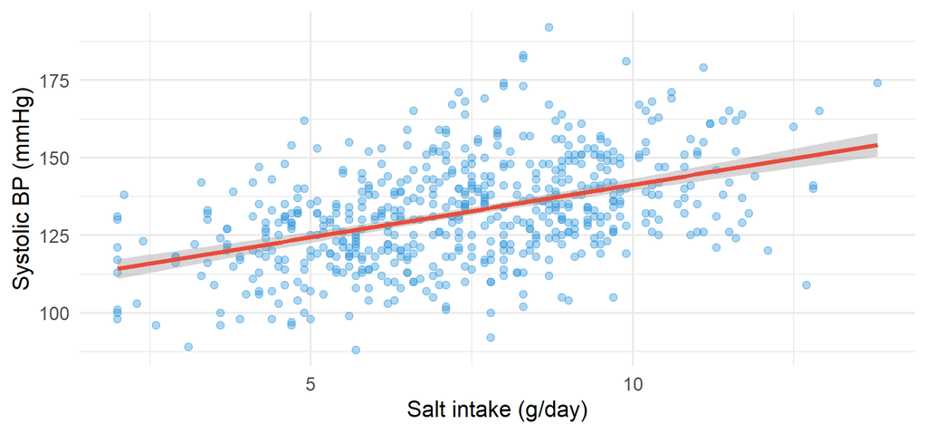

```r
ggplot(ncd, aes(salt_g, sbp)) +
  geom_point(alpha = .4, colour = col_blue) +
  geom_smooth(method = "lm", colour = col_red) +
  labs(x = "Salt intake (g/day)", y = "Systolic BP (mmHg)")
```

## `cor()` — and its limits

```r
ncd |> select(age, bmi, waist, salt_g, sbp) |>
  cor(use = "pairwise.complete.obs") |> round(2)
```

```
        age  bmi waist salt_g  sbp
age    1.00 0.18  0.16   0.35 0.46
bmi    0.18 1.00  0.95   0.41 0.33
waist  0.16 0.95  1.00   0.39 0.35
salt_g 0.35 0.41  0.39   1.00 0.45
sbp    0.46 0.33  0.35   0.45 1.00
```

- `use = "pairwise.complete.obs"` handles the missing values
- `sbp` and `salt_g`: moderate positive correlation — but **age and BMI also correlate with salt**
- `bmi` and `waist`: **r = 0.95**. Remember this — it comes back in Session 4

## 🔧 Switch to R — Lab 1

**File:** `regression-workshop/labs/lab1_explore.R`

- Import the CSV · glimpse · count missing values
- Build **Table 1** with `tbl_summary()` by hypertension
- Scatterplot of SBP vs salt · `cor()`

**Time:** 30 minutes · **Fill every** `___` · answer Q1–Q4 in the comments

## Self-check quiz (1/5)

A study asks: *Is tobacco use (yes/no) associated with having hypertension (yes/no), after adjusting for age?* Which model?

- Linear regression
- Logistic regression
- Cox regression
- Poisson regression for counts

## Self-check quiz (2/5)

Time from starting TB treatment to death, with some patients lost to follow-up (censored). Which model?

- Linear regression
- Poisson regression
- Cox regression
- Ordinal logistic

## Self-check quiz (3/5)

Which statement about correlation vs regression is TRUE?

- Correlation reports the change in Y per one-unit change in X
- Regression treats X and Y interchangeably, like correlation does
- Regression gives a slope in units and can include other variables
- Swapping X and Y changes the correlation but not the regression slope

## Self-check quiz (4/5)

A study records whether each patient is alive or dead one year after diagnosis. What type of outcome is this? (one word)

## Self-check quiz (5/5)

About 3% of salt_g values are missing and a model silently drops those people. What is this default approach called? (two words)

## Score and take-home

**Your score:**

- Regression = how the **average outcome** changes with predictors, **in real units**
- **Outcome type** → model (flowchart); today = linear and logistic
- Regression ≠ correlation: it has direction, units, adjustment and prediction
- Always **look at the data** first: Table 1, plots, missing values

**Next:** Session 2 — the straight line, prediction and R²